# Лабораторна робота № 4. Побудова моделей класифікації ІІ. Пакет tidymodels

**Мета:** *Засвоєння базових принципів, знайомство з інструментами та набуття навичок побудови, eкспорту та імпорту моделей класифікації на рівні технології на основі статистичного підходу та моделей машинного навчання засобами мови програмування R та за допомогою універсального інтерфейсу доступа до функцій машинного навчання пакету `tidymodels`.*

## 1 Підготовка середовища та даних

Для цієї роботи ми використовуємо набір даних `hw` (Height-Weight), що містить інформацію про зріст, вагу та стать людей. Наша мета — навчити модель розрізняти чоловіків та жінок.

Завантажимо необхідні бібліотеки. Для LDA в екосистемі `tidymodels` додатково потрібен пакет `discrim`.

```r
library(tidyverse)
library(tidymodels)
library(discrim)
library(DBI)
library(RSQLite)
library(knitr)
library(readxl)

theme_set(theme_light())
```

## 2 Імпорт та очищення даних

Зчитаємо дані з `xlsx`-файлу та підготуємо їх до моделювання: перейменуємо стовпці англійською мовою та перетворимо цільову змінну у фактор.

```r
raw_data <- read_excel("data/hw.xlsx")

hw_data <- raw_data %>%
  rename(Height = 1, Weight = 2, Gender = 3) %>%
  mutate(Gender = as.factor(Gender)) %>%
  filter(Height > 0, Weight > 0)

glimpse(hw_data)
```

```
Rows: 200
Columns: 3
$ Height <dbl> 175, 168, 173, 170, 171, 180, 188, 171, 190, 170, 178, 170, 175, 175,…
$ Weight <dbl> 87, 84, 63, 75, 72, 74, 85, 74, 76, 67, 80, 60, 75, 70, 84, 76, 89, 8…
$ Gender <fct> Man, Man, Man, Man, Man, Man, Man, Man, Man, Man, Man, Man, Man, Man,…
```

## 3 Розвідувальний аналіз (`EDA`)

Побудуємо графік розсіювання, щоб оцінити, наскільки добре розділяються класи чоловіків та жінок візуально. Це допоможе зрозуміти, чи ефективно спрацює лінійний розділювач (`LDA`).

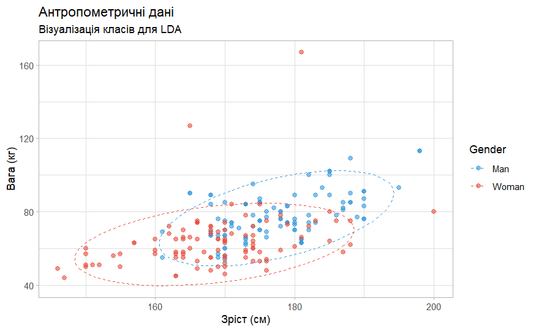

```r
ggplot(hw_data, aes(x = Height, y = Weight, color = Gender)) +
  geom_point(alpha = 0.6, size = 2) +
  scale_color_manual(values = c("Man" = "#3498db", "Woman" = "#e74c3c")) +
  labs(
    title = "Антропометричні дані",
    subtitle = "Візуалізація класів для LDA",
    x = "Зріст (см)",
    y = "Вага (кг)"
  ) +
  stat_ellipse(level = 0.95, linetype = 2)
```

Висновок `EDA`: Класи мають чіткі центри скупчення, хоча є зона перекриття. Лінійний дискримінантний аналіз тут має спрацювати добре.

## 4 Побудова моделі LDA

### 4.1 Розділення даних

Розбиваємо вибірку на тренувальну (75%) та тестову (25%).

```r
set.seed(2024)
hw_split <- initial_split(hw_data, prop = 0.75, strata = Gender)

train_set <- training(hw_split)
test_set  <- testing(hw_split)

cat("Тренувальна вибірка:", nrow(train_set), "рядків\n")
```

```
Тренувальна вибірка: 150 рядків
```

```r
cat("Тестова вибірка:", nrow(test_set), "рядків\n")
```

```
Тестова вибірка: 50 рядків
```

### 4.2 Специфікація моделі та Workflow

Створимо специфікацію для моделі `LDA` (`discrim_linear`) та об’єднаємо її з формулою в `workflow`. Використовуємо двигун `MASS`, який є стандартом для `LDA` в `R`.

```r
lda_spec <- discrim_linear() %>%
  set_engine("MASS") %>%
  set_mode("classification")

lda_workflow <- workflow() %>%
  add_model(lda_spec) %>%
  add_formula(Gender ~ Height + Weight)

lda_workflow
```

```
══ Workflow ══════════════════════════════════════════════════════════════════════════
Preprocessor: Formula
Model: discrim_linear()

── Preprocessor ──────────────────────────────────────────────────────────────────────
Gender ~ Height + Weight

── Model ─────────────────────────────────────────────────────────────────────────────
Linear Discriminant Model Specification (classification)

Computational engine: MASS
```

### 4.3 Навчання моделі

```r
lda_fit <- fit(lda_workflow, data = train_set)

lda_fit %>%
  extract_fit_engine()
```

```
Call:
lda(..y ~ ., data = data)

Prior probabilities of groups:
  Man Woman
  0.5   0.5

Group means:
        Height   Weight
Man   177.6667 78.02667
Woman 168.5333 63.92000

Coefficients of linear discriminants:
               LD1
Height -0.06178691
Weight -0.04153768
```

## 5 Оцінка якості моделі

Перевіримо точність класифікації на тестовій вибірці.

```r
predictions <- predict(lda_fit, test_set) %>%
  bind_cols(test_set)

conf_mat(predictions, truth = Gender, estimate = .pred_class)
```

```
          Truth
Prediction Man Woman
     Man    17     4
     Woman   8    21
```

```r
accuracy_metric <- accuracy(predictions, truth = Gender, estimate = .pred_class)
kable(accuracy_metric, caption = "Метрика точності моделі")
```

Метрика точності моделі

| .metric | .estimator | .estimate |
| --- | --- | --- |
| accuracy | binary | 0.76 |

## 6 Експорт та імпорт моделі через `SQLite`

Реалізуємо сценарій збереження навченої моделі у базу даних для подальшого використання.

```r
model_blob <- serialize(lda_fit, connection = NULL)

conn <- dbConnect(RSQLite::SQLite(), "classifier_models.db")

dbExecute(conn, "
  CREATE TABLE IF NOT EXISTS saved_models (
    id INTEGER PRIMARY KEY,
    name TEXT,
    data BLOB,
    timestamp TEXT
  )
")
```

```
[1] 0
```

```r
dbExecute(conn, "DELETE FROM saved_models WHERE name = 'gender_lda'")
```

```
[1] 0
```

```r
record <- tibble(
  name = "gender_lda",
  data = list(model_blob),
  timestamp = as.character(Sys.time())
)

dbAppendTable(conn, "saved_models", record)
```

```
[1] 1
```

```r
dbDisconnect(conn)

print("Модель успішно збережена в базу даних.")
```

```
[1] "Модель успішно збережена в базу даних."
```

### 6.1 Перевірка імпорту

Спробуємо завантажити модель назад і зробити прогноз для нової людини.

```r
conn <- dbConnect(RSQLite::SQLite(), "classifier_models.db")

loaded_rec <- dbGetQuery(conn, "SELECT data FROM saved_models WHERE name = 'gender_lda'")
dbDisconnect(conn)

imported_model <- unserialize(loaded_rec$data[[1]])

new_person <- data.frame(Height = 185, Weight = 90)
pred_result <- predict(imported_model, new_person)

cat("Прогноз для параметрів (185 см, 90 кг):", as.character(pred_result$.pred_class))
```

```
Прогноз для параметрів (185 см, 90 кг): Man
```